# Computer Programming and Algorithms

## Week 9.2: Plotting imported data

If you are opening the notebook in Google Colab, you can import the data files to use with the code cells throughout the notebook by running the code cell below:

```python
!wget https://raw.githubusercontent.com/engmaths/SEMT10002_2024/main/weekly_labs/Week_09_Modules_and_Plotting/temperature.csv
```

```
zsh:1: command not found: wget
```

# Aim

In this video we will show how to create plots of data imported from other files using `matplotlib.pyplot`

# Matplotlib

- Is a comprehensive package for creating static and dynamic visualisations in Python
- There are several elements of Matplotlib that handle different types of visualisation
- In this unit, we will focus on `matplotlib.pyplot` which is for plotting data

# Getting started

To import `matplotlib.pyplot` it is common to use the code

```python
import matplotlib.pyplot as plt
```

This should be placed at the top of your Python file

The `as` keyword is used to create our own, shorter name for `matplotlib.pyplot`; in this case, `plt`

# Loading some data to plot

Let's load in the temperature data so we can plot it

```python
import csv
with open('temperature.csv', 'r') as file:
    reader = csv.reader(file)
    data = list(reader)

print(data)
```

```
[['Time (hour)', 'Temperature (C)'], ['600', '10.3'], ['700', '10.6'], ['800', '12.1'], ['900', '12.7'], ['1000', '13.5'], ['1100', '14.3'], ['1200', '15.1']]
```

We now need to extract the time and temperature values and turn them into floats

```python
N_rows = len(data)

time = [float(data[n][0]) for n in range(1, N_rows)]
temp = [float(data[n][1]) for n in range(1, N_rows)]
```

# Creating a scatter plot

To plot this data as points on a scatter plot, using the `scatter` and `show` functions

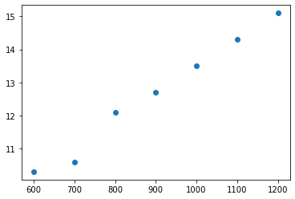

```python
plt.scatter(time, temp)
plt.show()
```

# Creating a line plot

To plot this data as a curve, we use the `plot` and `show` functions as follows

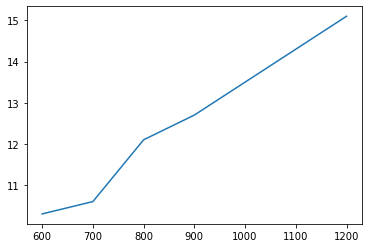

```python
plt.plot(time, temp)
plt.show()
```

# Spicing up the figure

- The plot that is produced is very basic and some important information is missing
  - A label for the $x$ axis
  - A label for the $y$ axis
- What if we want to change the colour, style, and thickness of the line?

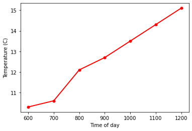

```python
plt.plot(time, temp, 'r.-', linewidth = 2, markersize = 10)
plt.xlabel("Time of day")
plt.ylabel("Temperature (C)")
plt.show()
```

# Saving your plot

The `savefig` function can be used to save your plot in different formats

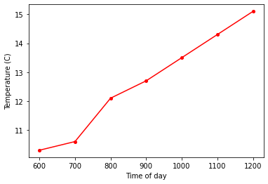

```python
plt.plot(time, temp, 'r.-', markersize = 8)
plt.xlabel('Time of day')
plt.ylabel('Temperature (C)')

# Save the figure as a PDF then PNG
plt.savefig('temperature_vs_time.pdf')
plt.savefig('temperature_vs_time.png')
```

# Summary

- `matplotlib.pyplot` contains functions for plotting data
- It is highly customisable, see [the Matplotlib website](https://matplotlib.org/stable/) for full details